# PB_CCS_workflow

### PacBio HiFi 质控，比对和SVs变异检测方面的相关软件

- 1. 质控软件主要有：
  - FastQC：适用于快速检查碱基质量分布、GC含量、序列长度分布等。
  - NanoPlot：专门用于长读长数据，能够生成详细的读长分布、质量分布等可视化图表。最近更新2023.10.29
  - [Nanofilt](https://github.com/wdecoster/nanofilt): 长读取测序数据的过滤和修整。最近更新 2022.12.21
  - [chopper](https://github.com/wdecoster/chopper/)： Rust implementation of NanoFilt+NanoLyse, both originally written in Python. This tool, intended for long read sequencing such as PacBio or ONT, filters and trims a fastq file. 最近更新 2024.08.20
- 2. 比对软件主要有：
  - minimap2：最近更新2024.03.27
  - [NGMLR](https://github.com/philres/ngmlr): 文章于2018年发表于Nature Methods，最近更新2018.06.25
  - [PBmm2](https://github.com/PacificBiosciences/pbmm2)：是PB官方基于minimap2进行优化的版本，最近更新2024.10.30
  - Winnowmap：一个基于minimap2改进的映射工具，它采用了独特的优化策略，尤其是在处理复杂重复区域时，如人类染色体中的长串联重复序列。最近更新2021.05.08
- 3. SVs变异检测软件主要有：
  - [PBSV](https://github.com/PacificBiosciences/pbsv)：PacBio官方开发的结构变异软件，最近更新2024.10.29
  - [Sniffles2](https://github.com/fritzsedlazeck/Sniffles)，版本一于2018年发表于Nature methods，最近更新2024.12.17
  - [cuteSV2](https://github.com/tjiangHIT/cuteSV)，文章于2020年发表于Genome Biology，最近更新2024.05.10
  - [PAV](https://github.com/EichlerLab/pav)，Phased Assembly Variant Caller，文章于2021年发表于Science，最近更新2024.12.18
  - DeBreak，文章于2023年发表在Nature Communication上，最近更新2022.12.01
  - [SVIM](https://github.com/eldariont/svim)，文章于2019年发表于Bioinformatics，最近更新2021.06.18
  - SVision, 文章于2022年发表于Nature Methods，最近更新2024.05.08

### 以下是两篇软件评估文章

- 评估文章：
- 第一篇文章于2024年发表在Genome Biology上, 文章强调Minimap2-cuteSV2、NGMLR-SVIM、PBMM2-pbsv、Winnowmap-Sniffles2 和 Winnowmap-SVision 等管道表现出相对较高的召回率和精度。
- 第二篇文章于2024年发表在Nature Communications上, 文章评论minimap2和winnowmap比对上优于ngmlr，但未对pbmm2进行评估，在pacbio hifi上，pbsv2整体表现较好

### 2024 GB 中山大学李淼新团队 Comprehensive and deep evaluation of structural variation detection pipelines with third-generation sequencing data

- (https://genomebiology.biomedcentral.com/articles/10.1186/s13059-024-03324-5)
- 文章结果： 值得注意的是，Minimap2-cuteSV2、NGMLR-SVIM、PBMM2-pbsv、Winnowmap-Sniffles2 和 Winnowmap-SVision 等管道表现出相对较高的召回率和精度。

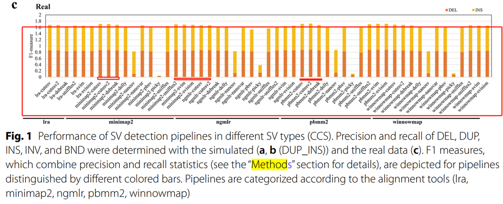

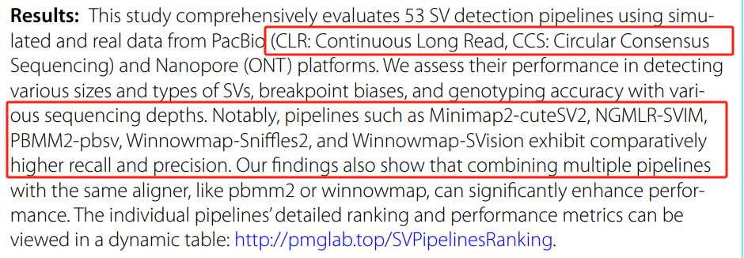

### 2024 NC Tradeoffs in alignment and assembly-based methods for structural variant detection with long-read sequencing data

- https://doi.org/10.1038/s41467-024-46614-z
- 文章首先系统地分析和评估了 2014 年至 2022 年间在大量 PacBio 和 ONT 数据集上引入的 16 种最先进的长读长 SV 方法的性能。
- 不同比对工具：
  - a） 不同的对准器对基于对齐的工具的插入召回率有显着影响。一般来说，对于大多数基于比对的工具，minimap2、Winnowmap 和 LRA 在插入召回方面优于 NGMLR。
  - b） 插入精度、删除召回率和精度不受影响，或者仅受不同对准器的细微影响
- 不同的SV caller：
  - a） 对于易位，在模拟数据上，总体最佳工具是 cuteSV 和 pbsv（在所有合适的数据集上 F1 > 0.95），其次是 NanoSV 和 SVIM。
  - b） 对于倒置，没有工具达到高性能。NanoVar、Sniffles2 和 NanoVar 分别在 Hifi、CLR 和 ONT 上获得了最好的 F1 分数。
  - c） 对于重复，pbsv 是 Hifi 和 CLR 数据的最佳工具，其次是 DeBreak，而 NanoVar 是 ONT 数据的最佳工具。

### 对pacbio hifi测序数据进行SV检测的文章：

### 2024 Cell 上海交通大学毛亚飞 Structurally divergent and recurrently mutated regions of primate genomes

- 文章中通过minimap2比对，SVs检测是PAV, pbsv, and Sniffles进行检测，然后再通过SV-pop tool进行合并SVs
- https://doi.org/10.1016/j.cell.2024.01.052

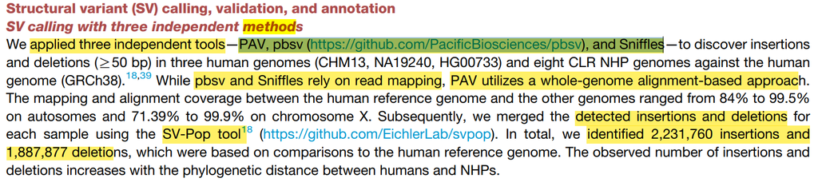

- 2024 NC [泛基因组图改进了对罕见遗传病结构变异的分析](https://doi.org/10.1038/s41467-024-44980-2)： 做的泛基因组，流程是minigraph + pbsv
- 2023 GB [利用HiFi长阅读测序进行全面的从头突变发现](https://genomemedicine.biomedcentral.com/articles/10.1186/s13073-023-01183-6)：分析流程是：pbmm2 + pbsv
- 2023 GM [利用HiFi长阅读测序进行全面的从头突变发现](https://link.springer.com/article/10.1186/s13073-023-01183-6) 分析流程是：pbmm2 + pbsv